# Reduced Order Model for non-linear Schrödinger Equation

Mohamad Nabizadeh

3/7/2022

# Problem definition

The objective of this report is to present a numerical solution for the non-linear Schrödinger equation and to showcase the applicability of reduced order model on such computationally exhaustive problems. Schrödinger equation can be written as follows:

$$i u_t + \frac{1}{2}u_{xx}+|u|^2 u = 0,$$
Where $u$ is the physical state of the system, $u_t$ is the time derivative, $u_{xx}$ is the second spatial derivative, and $|u|$ is a scalar representing the absolute size of $u$. To solve this ODE, first, let’s keep $u_t$ on the left hand side of the equation and take all the other terms to the right hand side, and multiply both sides by $-i$, we get:

$$u_t = \frac{i}{2}u_{xx} +i|u|^2 u$$
# Numerical solution

We can now use Fourier basis algorithm to computationally solve this equation, taking Fourier transform of both sides gives the following:

$$\hat{u_t} = -\frac{i}{2}k^2\hat{u} + i FT(|u|^2 u)$$
Now we can use this first order ODE, and solve it in a time-stepper loop. A sample code is imlemented in Matlab.

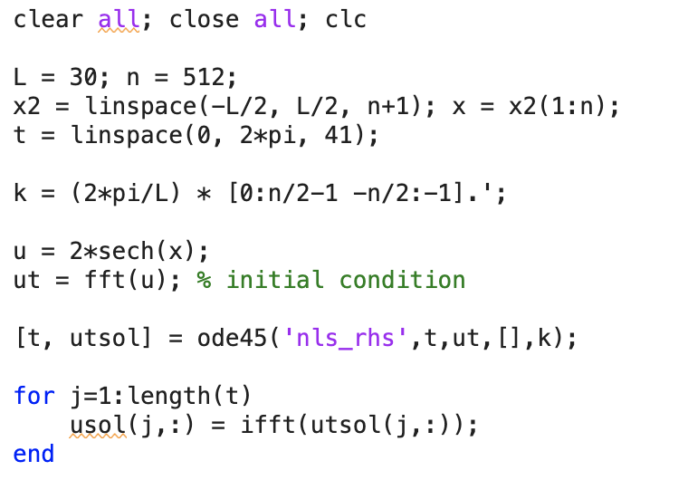

where the **nls_rhs** is defined as:

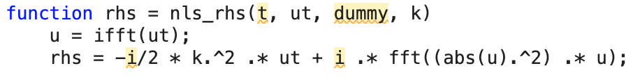

## Results

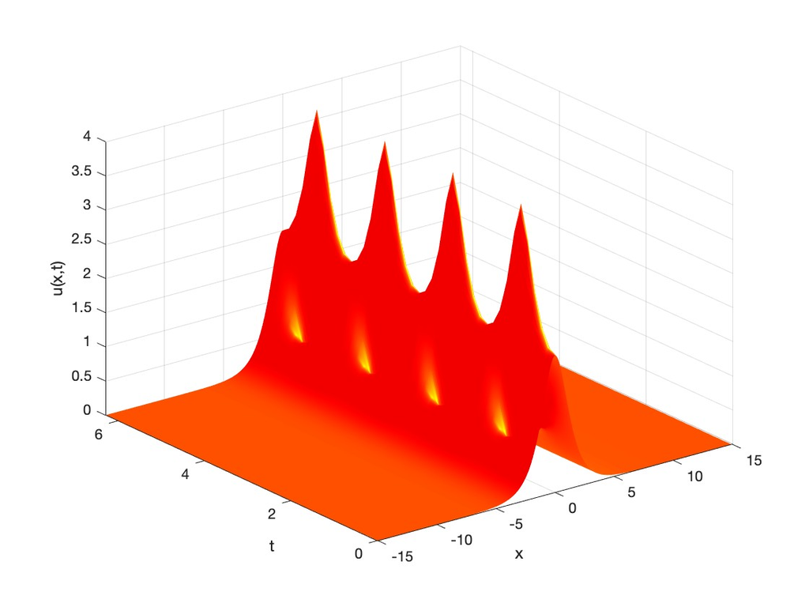

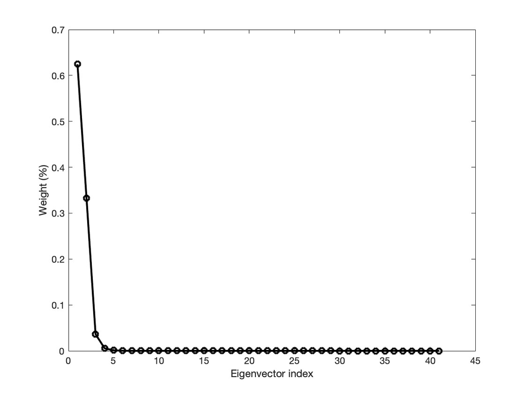

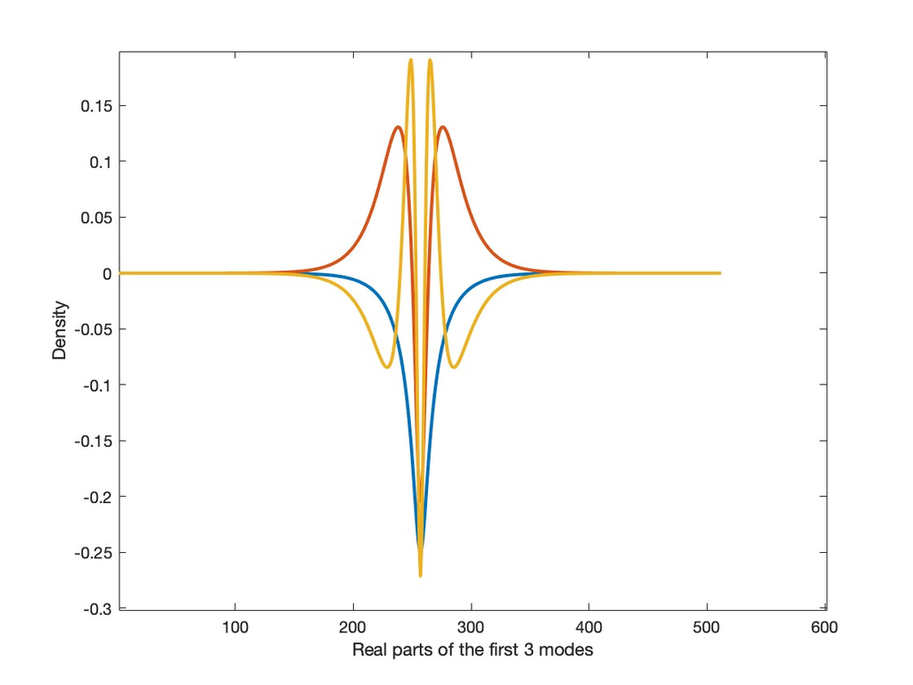

1. Surface plot of the numeric solution, (b) weights of different modes in percentage, and (c) Top three modes.

# Reduced order modeling

## First-order model

Despite the high dimensional nature of the problem, we see -both visually and quantitatively- that 3 orthogonal components can explain more than $99\%$ of the standard deviation in the answer. Therefore, we’re planning to use only those components to build the solution. First, let’s consider only one component. Let’s use separation of variables:

$$u = a(t) \psi(t),$$

where,

$$\psi(t) = [\psi_1]$$

$$i a^\prime \psi = \frac{1}{2} a \psi_xx + |a|^2a |\psi^2| \psi$$
there is only one mode, and we know that the inner product of each component by itself is:

$$\psi . \psi = 1$$
Plug that in:

$$ia^\prime = \frac{1}{2} a (\psi_{xx}.\psi ) + |a|^2 a (|\psi|^2 \psi.\psi )$$
Therefore, in the case of reducing the order to 1, we get to the following ODE:
$$ia_t + \frac{\alpha}{2} a + \beta |a|^2 a = 0,$$

which in fact has the following analytical solution.

$$a(t) = a(0) e^{[i\frac{\alpha}{2} +\beta|a(0)|^2t]}$$
But, we know that existence of an analytical solution is highly unlikely for higher orders and we’ll need numerical techniques to aquire a solution.

## Third-order model

Let’s use the first three orthogonal components now, rewrite the ODE first:

$$u_t = \frac{i}{2} u_xx + i|u|^2 u,$$

From seperation of variables, we have:

$$u = \phi(x) a(t)$$
Also, we have from eigenvalue decomposition the following:

$$X = U\Sigma V^{*},$$
where,

$$U = \phi_r,$$

Let’s plug that into our ODE:

$$a^{\prime} = \frac{i}{2} \phi_r^T \phi_{xx} + i\phi_r^T |\phi_r a|^2 \phi_r a$$

Which is our approximation of the solution for this 2D system. Apart from the equation, we also need initial conditions, where $sech(x)$ is proposed as an appropriate initial condition for $u(x,0)$. Therefore:

$$u(0) = 2 sech(x)= \phi_r a(0),$$

$$a(0) = \phi_r^T \times (2sech(x))$$
Having established the reduced order model, and the initial conditions, we can now proceed to the implementation of the model, but before that, let’s quickly remind about how we calculate a second derivative by the means of Fourier transform.

$$\phi^i_{xx} = IFFT(-k^2 . FFT(\phi^i_r))$$
Let’s now take a look at our implementation in Matlab:

### Implementation

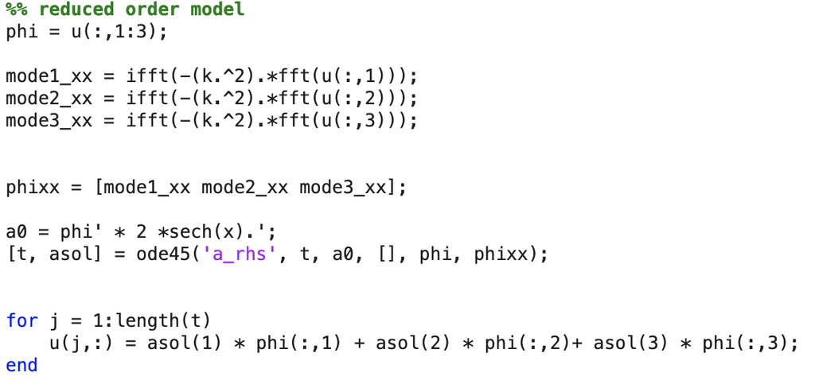

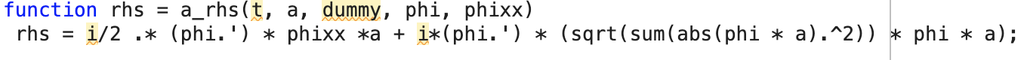

### Results

We can see that using the top three vectors, we can build a model that can reproduce a solution that closely resembles that of the original problem. This is a great example on how reduced order modeling can provide much more efficient solutions with minor loss of information.

[figure not shown]

Credit for the codes of this notebook goes to [Nathan Kutz](https://www.youtube.com/channel/UCoUOaSVYkTV6W4uLvxvgiFA).